[figure not shown]

# Score de Prospecção

> Este relatório apresenta todo o processo inicial para a classificação do sucesso ou falha ao contatar determinado CNPJ para a oferta de credito pela empresa ATF.Credit. Todo o processo utilizado para a criação de uma solução eficiente foi desenvolvido na linguagem de programação Python, utilizando como armazenamento o banco de dados não relacional MongoDB. Ao decorrer do relatório será explicado toda a metodología utilizada, as técnicas aplicadas e os passos futuros para o desenvolvimento de um modelo preciso e consitente.

## Definição do problema

> Como dito anteriormente, o objetivo deste trabalho é realizar uma classificação binaria. Para isso, foram disponibilizadas informações sobre **100 cnpj's** em formato de arquivo de texto. Sendo assim, o problema geral é definido, não apenas como um problema de classificação, mas também de limpeza e tratamento de dados, uma vez que os dados tem diversas origens e uma inconstancia de informações.

## 1. Tratamento Inicial

> A primeira etapa realizada no processo de solução do problema definido a cima, foi dada pela aquisição e interpretação dos txt's, seguido conversão dos arquivos em tabelas e do armazenamento em um banco de dados local e não relacional (**MongoDB**).

## 2. Limpeza dos Dados

> Os códigos apresentados a baixo fazem referência a limpeza dos dados e conversão das informações presentes nos txt's em parámetros que podem ser utilizadas no modelo de Aprendizado de Máquina (*Machine Learning*), uma vez que os dados ja foram convertidos em tabelas e armazenadas em um MongoDB.

### Tamanho da Base

> > Apesar de terem sido disponibilizados **100 txts**, só foram possivel ser interpretado de forma satisfatoria apenas **91**

### Parámetros Utilizados

> > Foram cedidos pela ATF.Credit a informação sobre 10 parámetros para serem utilizados no processo de predição. Entretanto, os dados disponibilizados apresentavam uma baixa quantidade desses parametros como pode ser viso no gráfico de barras abaixo:

[interactive chart not shown]

## 3. Parâmetros Utilizados

### 3.1 Consultas Importântes

> > A tabela abaixo faz referência as empresas que consultaram determinado CNPJ. A partir dela, o parâmetro utilizado seria a quantidade de empresas do segmento *factoring* encontrado na coluna **EMPRESA** da tabela.

> > O gráfico apresenta os valores encontrados no parâmetro utilizado

|  | EMPRESA | QTD | DATA |
| --- | --- | --- | --- |
| 0 | NOVA AMERICA FACTORING LTDA | 1 | 15/04/2019 |
| 1 | REI ESPUMAS COM PLASTICOS COLCH | 1 | 12/04/2019 |
| 2 | RED SA | 1 | 11/04/2019 |
| 3 | CEF | 2 | 10/04/2019 |
| 4 | COOPERATIVA CEN ECON CRED MUTUO | 1 | 09/04/2019 |

[interactive chart not shown]

### 3.2 Consultas Recentes

> > A tabela utilizada para a criação desse parametro pode ser vista abaixo

> > Dado os ultimos 2 meses apresentados, caso a quantidade de consultas fosse maior que 30% da media o parâmetro seria definido como 1 e 0 caso contrario. Seria definido -1 caso a CNPJ nao apresentasse essa informação

> > A distribuição dos dados pode ser visto no grafico de barras abaixo:

|  | MES | QTD |
| --- | --- | --- |
| 0 | MAR/19 | 10 |
| 1 | FEV/19 | 19 |
| 2 | JAN/19 | 25 |
| 3 | DEZ/18 | 17 |
| 4 | NOV/18 | 14 |
| 5 | OUT/18 | 9 |
| 6 | AGO/18 | 18 |
| 7 | JUL/18 | 20 |
| 8 | JUN/18 | 17 |
| 9 | MAI/18 | 12 |
| 10 | ABR/18 | 14 |
| 11 | MAR/18 | 12 |

[interactive chart not shown]

### 3.3 Total de Consultas

> > Utilizando a mesma tabela do parâmetro a cima, esse parâmetro é definido apenas pelo somatorio das consultas realizadas

> > A distribuição dos dados pode ser visto no grafico de caixa abaixo:

[interactive chart not shown]

### 3.4 Evolução de Compromissos

> > A tabela utilizada para a criação desse parametro pode ser vista abaixo:

> > O calculo desse parametro é feito tomando como base a coluna de **VENCIDOS** e **A VENCER**, caso exista algum valor em uma dessas colunas nas 3 primeiras linhas, o valor de **0.8** é atribuido ao parâmetros por cada linha com valor presente, caso as outras linhas apresentem valores nessas colunas, é atribuido **0.2**.

> > A distribuição dos dados pode ser visto no grafico de barras abaixo:

|  | MES/ANO | VENCIDOS | A VENCER | TOTAL |
| --- | --- | --- | --- | --- |
| 0 | ABR/19 | 71.420 | 2662.960 | 2.734.380 |
| 1 | MAR/19 | 61.388 | 2785.381 | 2.846.769 |
| 2 | FEV/19 | 12.852 | 1928.315 | 1.941.167 |
| 3 | JAN/19 | 187.550 | 908.269 | 1.095.819 |
| 4 | DEZ/18 | 19.795 | 1954.514 | 1.974.309 |
| 5 | NOV/18 | 19.234 | 3470.030 | 3.489.264 |
| 6 | OUT/18 | 30.442 | 2796.604 | 2.827.046 |
| 7 | SET/18 | 28.281 | 5604.404 | 5.632.685 |
| 8 | AGO/18 | 34.684 | 6921.713 | 6.956.397 |
| 9 | JUL/18 | 27.010 | 5565.894 | 5.592.904 |
| 10 | JUN/18 | 44.921 | 5192.494 | 5.237.415 |
| 11 | MAI/18 | 49.886 | 4799.309 | 4.849.195 |
| 12 | ABR/18 | 11.906 | 3901.443 | 3.913.349 |
| 13 | MAR/18 | 42.756 | 3024.363 | 3.067.119 |

[interactive chart not shown]

### 3.5 HISTORICO DE PAGAMENTOS

> > A tabela utilizada para a criação desse parametro pode ser vista abaixo:

> > O calculo desse parametro é feito tomando como base 4 colunas e atribuindo um determinado valor ao parametro caso a coluna em questão apresente alguma informação, os valores atribuidos para cada coluna são:
> > - **8-15_QTD**: 0.3
> > - **16-30_QTD**: 0.5
> > - **31-60_QTD**: 0.7
> > - **+60_QTD**: 0.9

> > A distribuição dos dados pode ser visto no grafico de caixa abaixo:

|  | MES/ANO | PONTUAL_QTD | PONTUAL_ | 8-15_QTD | 8-15_% | 16-30_QTD | 16-30_% | 31-60_QTD | 31-60_% | +60_QTD | +60_% | A_VISTA_QTD | A_VISTA_% |
| --- | --- | --- | --- | --- | --- | --- | --- | --- | --- | --- | --- | --- | --- |
| 0 | NOV/19 | 300 MIL A 400 MIL | 93,00% A 95,00% | 5,5 MIL A 6 MIL | 1,00% A 3,00% | 5 MIL A 5,5 MIL | 1,00% A 3,00% | 10 MIL A 13 MIL | 1,00% A 3,00% | None | None | None | None |
| 1 | OUT/19 | 300 MIL A 400 MIL | 95,00% A 97,00% | None | None | 10 MIL A 13 MIL | 3,00% A 5,00% | None | None | None | None | None | None |
| 2 | SET/19 | 300 MIL A 400 MIL | 97,00% A 100,00% | None | None | 8,5 MIL A 9 MIL | 1,00% A 3,00% | None | None | None | None | None | None |
| 3 | AGO/19 | 100 MIL A 200 MIL | 93,00% A 95,00% | 10 MIL A 13 MIL | 5,00% A 7,00% | None | None | None | None | None | None | None | None |
| 4 | JUL/19 | 6 MIL A 6,5 MIL | 97,00% A 100,00% | None | None | None | None | None | None | None | None | None | None |

[interactive chart not shown]

## 4. Analize inicial

> Após o processo de limpeza e tratamento, é obtido a tabela abaixo com um total de **84 linhas** e **7 colunas**, com os valores encontrados pela busca de parâmetros a cima. Vale salientar que na coluna **y** é onde encontra-se o resultado ao contatar o cliente, sendo **1: Sucesso** e **0: Falha**

> Uma amostra da tabela pode ser vista abaixo

|  | cnpj | y | ConsultasCredito | ConsultasRecentes | Total_Consultas | EvolucaoCompromissos | HistoricoPagamentos |
| --- | --- | --- | --- | --- | --- | --- | --- |
| 0 | 95.816.963/0001-74 | 0.0 | 0.0 | 0 | 187 | 4.6 | -1.0 |
| 1 | 03.943.986/0001-21 | 1.0 | 0.0 | 0 | 207 | 2.6 | 0.0 |
| 2 | 13.056.177/0003-13 | 0.0 | 0.0 | 0 | 878 | 4.4 | -1.0 |
| 3 | 78.099.777/0001-42 | 1.0 | 0.0 | 1 | 561 | 4.4 | -1.0 |
| 4 | 00.325.400/0001-77 | 0.0 | 0.0 | 0 | 177 | 4.6 | -1.0 |

### Distribuição dos valores

> > O gráfico abaixo apresenta a distribuição dos valores em formato de um grafico de pontos, levando em consideração o Historico de Pagamentos e o número Total de Consultas.

[interactive chart not shown]

> > A partir de uma breve analise do gráfico a cima é possivel identificar algumas carateristicas nos dados, sendo elas:
> > - A maioria dos casos de insucesso não apresentam um Historico de Pagamentos, sendo representado por **-1**
> > - Grande quantidade dos casos de sucesso se encontrar com menos de 600 consultas e com Historico de pagamentos maior ou igual a zero

## 5. Classificação CNPJ

> Nessa etapa do processo, foi realizado a classificação entre sucesso(**1**) e falha(**0**) utilizando os **84** dados obtidos após todo o processo de captura e limpeza. Sendo assim, o processo de treinamento de um modelo de *Machine Learning* foi realizado dividindo a base em 75% para treino (**63 dados**) e 25% para teste (**21 dados**)

> Cada valor encontrado no conjunto de dados representando a classificação, nós chamamos de **classe**. Sendo assim, para um processo de Aprendizado de Máquina satisfatorio é necessário que as classes estejam minimamente divididas entre os conjuntos de treino e de teste. Essa divisão pode ser visualizada no gráfico abaixo:

[interactive chart not shown]

### 5.1 *Support Vector Classification*

> > Após alguns testes realizados, o melhor algoritmo encontrado foi o *Support Vector Classification*(SVC) com a otimização do gradiente descendente estocástico. O SVC é uma variação do *Support Vector Machine* que é um algoritmo supervisionado que através de operações vetoriais para aumento de dimensionalidade tenta criar um hiperplano que melhor separe os dados. O funcionamento do algoritmo pode ser melhor entendido atraves do giff abaixo

[figure not shown]

### 5.2 Métricas Utilizadas

> > Para Validação do modelo foram utilizadas 3 metricas, sendo elas:
> > - *Accuracy*: Indica uma performance geral do modelo. Dentre todas as classificações, quantas o modelo classificou corretamente.
> > - *Precisçao*: Indica dentre todas as classificações de classe Positivo que o modelo fez, quantas estão corretas;
> > - *Recal(Revocação)*: Indica dentre todas as situações de classe Positivo como valor esperado, quantas estão corretas; O calculo de cada metrica é simples e pode ser visto abaixo, onde cada variavel é oriunda da matriz de confusão explicada logo em seguida

[figure not shown]

> > **5.2.1 Matriz de Confusão**

> > A matriz de confusão indica a quantidade de erros e acertos do modelo, comparando com o resultado esperado:

[figure not shown]

# 6. Resultados Obtidos

> > - Accuracy: **0.90**

> > **Matriz de Confusão:**

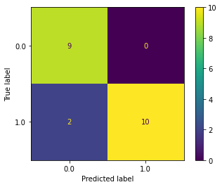

# 7. Próximos Passos

> Como mostrado nesse trabalho, já é possivel valdiar a aplicabilidade de uma solução. Entretanto, apesar dos bons resultados alcançados nesse trabalho, vale salientar que todos os testes foram realizados em um conjunto de dados pequenos que não refletem a realidade por completo. Sendo assim, os proximos passos devem ser a captura de mais dados consistentes, juntamente com a analise de novos parametros para conseguir resultados cada vez mais confiaveis. Além disso, uma proxima etapa tambem deve ser a transformação de uma classificação binaria em uma regressão para um score entre 0 e 100, atraves de algoritmos de aprendizado não supervisionados.